# Risk Factor Analysis

## Outcome Variable

**Outcome Variable:** pers_wast

## Predictor Variables

**Intervention Variable:** feducyrs

**Adjustment Set:**

- arm
- W_mage
- meducyrs
- W_mhtcm
- W_mwtkg
- W_mbmi
- W_gagebrth
- W_birthwt
- W_birthlen
- single
- delta_W_mage
- delta_meducyrs
- delta_W_mhtcm
- delta_W_mwtkg
- delta_W_mbmi
- delta_W_gagebrth
- delta_W_birthwt
- delta_W_birthlen
- delta_single

## Stratifying Variables

The analysis was stratified on these variable(s):

- agecat
- studyid
- country

## Data Summary

| agecat | studyid | country | feducyrs | pers_wast | n_cell | n |
| --- | --- | --- | --- | --- | --- | --- |
| 0-24 months | ki0047075b-MAL-ED | BANGLADESH | High | 0 | 48 | 138 |
| 0-24 months | ki0047075b-MAL-ED | BANGLADESH | High | 1 | 3 | 138 |
| 0-24 months | ki0047075b-MAL-ED | BANGLADESH | Low | 0 | 38 | 138 |
| 0-24 months | ki0047075b-MAL-ED | BANGLADESH | Low | 1 | 0 | 138 |
| 0-24 months | ki0047075b-MAL-ED | BANGLADESH | Medium | 0 | 45 | 138 |
| 0-24 months | ki0047075b-MAL-ED | BANGLADESH | Medium | 1 | 4 | 138 |
| 0-24 months | ki0047075b-MAL-ED | INDIA | High | 0 | 43 | 139 |
| 0-24 months | ki0047075b-MAL-ED | INDIA | High | 1 | 0 | 139 |
| 0-24 months | ki0047075b-MAL-ED | INDIA | Low | 0 | 51 | 139 |
| 0-24 months | ki0047075b-MAL-ED | INDIA | Low | 1 | 4 | 139 |
| 0-24 months | ki0047075b-MAL-ED | INDIA | Medium | 0 | 32 | 139 |
| 0-24 months | ki0047075b-MAL-ED | INDIA | Medium | 1 | 9 | 139 |
| 0-24 months | ki0047075b-MAL-ED | NEPAL | High | 0 | 40 | 96 |
| 0-24 months | ki0047075b-MAL-ED | NEPAL | High | 1 | 1 | 96 |
| 0-24 months | ki0047075b-MAL-ED | NEPAL | Low | 0 | 27 | 96 |
| 0-24 months | ki0047075b-MAL-ED | NEPAL | Low | 1 | 0 | 96 |
| 0-24 months | ki0047075b-MAL-ED | NEPAL | Medium | 0 | 27 | 96 |
| 0-24 months | ki0047075b-MAL-ED | NEPAL | Medium | 1 | 1 | 96 |
| 0-24 months | ki0047075b-MAL-ED | PERU | High | 0 | 110 | 234 |
| 0-24 months | ki0047075b-MAL-ED | PERU | High | 1 | 1 | 234 |
| 0-24 months | ki0047075b-MAL-ED | PERU | Low | 0 | 63 | 234 |
| 0-24 months | ki0047075b-MAL-ED | PERU | Low | 1 | 0 | 234 |
| 0-24 months | ki0047075b-MAL-ED | PERU | Medium | 0 | 60 | 234 |
| 0-24 months | ki0047075b-MAL-ED | PERU | Medium | 1 | 0 | 234 |
| 0-24 months | ki0047075b-MAL-ED | SOUTH AFRICA | High | 0 | 38 | 99 |
| 0-24 months | ki0047075b-MAL-ED | SOUTH AFRICA | High | 1 | 0 | 99 |
| 0-24 months | ki0047075b-MAL-ED | SOUTH AFRICA | Low | 0 | 35 | 99 |
| 0-24 months | ki0047075b-MAL-ED | SOUTH AFRICA | Low | 1 | 1 | 99 |
| 0-24 months | ki0047075b-MAL-ED | SOUTH AFRICA | Medium | 0 | 25 | 99 |
| 0-24 months | ki0047075b-MAL-ED | SOUTH AFRICA | Medium | 1 | 0 | 99 |

[output cut: 294 more lines]

The following strata were considered:

- agecat: 0-24 months, studyid: ki0047075b-MAL-ED, country: BANGLADESH
- agecat: 0-24 months, studyid: ki0047075b-MAL-ED, country: INDIA
- agecat: 0-24 months, studyid: ki0047075b-MAL-ED, country: NEPAL
- agecat: 0-24 months, studyid: ki0047075b-MAL-ED, country: PERU
- agecat: 0-24 months, studyid: ki0047075b-MAL-ED, country: SOUTH AFRICA
- agecat: 0-24 months, studyid: ki0047075b-MAL-ED, country: TANZANIA, UNITED REPUBLIC OF
- agecat: 0-24 months, studyid: ki1000304b-SAS-CompFeed, country: INDIA
- agecat: 0-24 months, studyid: ki1000304b-SAS-FoodSuppl, country: INDIA
- agecat: 0-24 months, studyid: ki1017093b-PROVIDE, country: BANGLADESH
- agecat: 0-24 months, studyid: ki1017093c-NIH-Crypto, country: BANGLADESH
- agecat: 0-24 months, studyid: ki1066203-TanzaniaChild2, country: TANZANIA, UNITED REPUBLIC OF
- agecat: 0-24 months, studyid: ki1113344-GMS-Nepal, country: NEPAL
- agecat: 0-24 months, studyid: ki1119695-PROBIT, country: BELARUS
- agecat: 0-24 months, studyid: ki1126311-ZVITAMBO, country: ZIMBABWE
- agecat: 0-24 months, studyid: ki1135781-COHORTS, country: GUATEMALA
- agecat: 0-24 months, studyid: ki1135781-COHORTS, country: INDIA
- agecat: 0-24 months, studyid: ki1135781-COHORTS, country: PHILIPPINES
- agecat: 0-24 months, studyid: ki1148112-LCNI-5, country: MALAWI
- agecat: 0-24 months, studyid: kiGH5241-JiVitA-3, country: BANGLADESH
- agecat: 0-24 months, studyid: kiGH5241-JiVitA-4, country: BANGLADESH
- agecat: 0-6 months, studyid: ki0047075b-MAL-ED, country: BANGLADESH
- agecat: 0-6 months, studyid: ki0047075b-MAL-ED, country: INDIA
- agecat: 0-6 months, studyid: ki0047075b-MAL-ED, country: NEPAL
- agecat: 0-6 months, studyid: ki0047075b-MAL-ED, country: PERU
- agecat: 0-6 months, studyid: ki0047075b-MAL-ED, country: SOUTH AFRICA
- agecat: 0-6 months, studyid: ki0047075b-MAL-ED, country: TANZANIA, UNITED REPUBLIC OF
- agecat: 0-6 months, studyid: ki1017093b-PROVIDE, country: BANGLADESH
- agecat: 0-6 months, studyid: ki1017093c-NIH-Crypto, country: BANGLADESH
- agecat: 0-6 months, studyid: ki1066203-TanzaniaChild2, country: TANZANIA, UNITED REPUBLIC OF
- agecat: 0-6 months, studyid: ki1113344-GMS-Nepal, country: NEPAL
- agecat: 0-6 months, studyid: ki1119695-PROBIT, country: BELARUS
- agecat: 0-6 months, studyid: ki1126311-ZVITAMBO, country: ZIMBABWE
- agecat: 0-6 months, studyid: ki1135781-COHORTS, country: PHILIPPINES
- agecat: 0-6 months, studyid: kiGH5241-JiVitA-3, country: BANGLADESH
- agecat: 6-24 months, studyid: ki0047075b-MAL-ED, country: BANGLADESH
- agecat: 6-24 months, studyid: ki0047075b-MAL-ED, country: INDIA
- agecat: 6-24 months, studyid: ki0047075b-MAL-ED, country: NEPAL
- agecat: 6-24 months, studyid: ki0047075b-MAL-ED, country: PERU
- agecat: 6-24 months, studyid: ki0047075b-MAL-ED, country: SOUTH AFRICA
- agecat: 6-24 months, studyid: ki0047075b-MAL-ED, country: TANZANIA, UNITED REPUBLIC OF
- agecat: 6-24 months, studyid: ki1000304b-SAS-CompFeed, country: INDIA
- agecat: 6-24 months, studyid: ki1000304b-SAS-FoodSuppl, country: INDIA
- agecat: 6-24 months, studyid: ki1017093b-PROVIDE, country: BANGLADESH
- agecat: 6-24 months, studyid: ki1017093c-NIH-Crypto, country: BANGLADESH
- agecat: 6-24 months, studyid: ki1066203-TanzaniaChild2, country: TANZANIA, UNITED REPUBLIC OF
- agecat: 6-24 months, studyid: ki1113344-GMS-Nepal, country: NEPAL
- agecat: 6-24 months, studyid: ki1119695-PROBIT, country: BELARUS
- agecat: 6-24 months, studyid: ki1126311-ZVITAMBO, country: ZIMBABWE
- agecat: 6-24 months, studyid: ki1135781-COHORTS, country: GUATEMALA
- agecat: 6-24 months, studyid: ki1135781-COHORTS, country: INDIA
- agecat: 6-24 months, studyid: ki1135781-COHORTS, country: PHILIPPINES
- agecat: 6-24 months, studyid: ki1148112-LCNI-5, country: MALAWI
- agecat: 6-24 months, studyid: kiGH5241-JiVitA-3, country: BANGLADESH
- agecat: 6-24 months, studyid: kiGH5241-JiVitA-4, country: BANGLADESH

### Dropped Strata

Some strata were dropped due to rare outcomes:

- agecat: 0-24 months, studyid: ki0047075b-MAL-ED, country: BANGLADESH
- agecat: 0-24 months, studyid: ki0047075b-MAL-ED, country: INDIA
- agecat: 0-24 months, studyid: ki0047075b-MAL-ED, country: NEPAL
- agecat: 0-24 months, studyid: ki0047075b-MAL-ED, country: PERU
- agecat: 0-24 months, studyid: ki0047075b-MAL-ED, country: SOUTH AFRICA
- agecat: 0-24 months, studyid: ki0047075b-MAL-ED, country: TANZANIA, UNITED REPUBLIC OF
- agecat: 0-24 months, studyid: ki1017093b-PROVIDE, country: BANGLADESH
- agecat: 0-24 months, studyid: ki1017093c-NIH-Crypto, country: BANGLADESH
- agecat: 0-24 months, studyid: ki1148112-LCNI-5, country: MALAWI
- agecat: 0-6 months, studyid: ki0047075b-MAL-ED, country: BANGLADESH
- agecat: 0-6 months, studyid: ki0047075b-MAL-ED, country: INDIA
- agecat: 0-6 months, studyid: ki0047075b-MAL-ED, country: NEPAL
- agecat: 0-6 months, studyid: ki0047075b-MAL-ED, country: PERU
- agecat: 0-6 months, studyid: ki0047075b-MAL-ED, country: SOUTH AFRICA
- agecat: 0-6 months, studyid: ki0047075b-MAL-ED, country: TANZANIA, UNITED REPUBLIC OF
- agecat: 0-6 months, studyid: ki1017093b-PROVIDE, country: BANGLADESH
- agecat: 0-6 months, studyid: ki1017093c-NIH-Crypto, country: BANGLADESH
- agecat: 0-6 months, studyid: ki1126311-ZVITAMBO, country: ZIMBABWE
- agecat: 0-6 months, studyid: kiGH5241-JiVitA-3, country: BANGLADESH
- agecat: 6-24 months, studyid: ki0047075b-MAL-ED, country: BANGLADESH
- agecat: 6-24 months, studyid: ki0047075b-MAL-ED, country: INDIA
- agecat: 6-24 months, studyid: ki0047075b-MAL-ED, country: NEPAL
- agecat: 6-24 months, studyid: ki0047075b-MAL-ED, country: PERU
- agecat: 6-24 months, studyid: ki0047075b-MAL-ED, country: SOUTH AFRICA
- agecat: 6-24 months, studyid: ki0047075b-MAL-ED, country: TANZANIA, UNITED REPUBLIC OF
- agecat: 6-24 months, studyid: ki1017093b-PROVIDE, country: BANGLADESH
- agecat: 6-24 months, studyid: ki1017093c-NIH-Crypto, country: BANGLADESH
- agecat: 6-24 months, studyid: ki1148112-LCNI-5, country: MALAWI

## Methods Detail

We’re interested in the causal parameters $E[Y_a]$ for all values of $a \in \mathcal{A}$. These parameters represent the mean outcome if, possibly contrary to fact, we intervened to set all units to have $A=a$. Under the randomization and positivity assumptions, these are identified by the statistical parameters $\psi_a=E_W[E_{Y|A,W}(Y|A=a,W)]$. In addition, we’re interested in the mean of $Y$, $E[Y]$ under no intervention (the observed mean). We will estimate these parameters by using SuperLearner to fit the relevant likelihood factors – $E_{Y|A,W}(Y|A=a,W)$ and $p(A=a|W)$, and then updating our likelihood fit using a joint TMLE.

For unadjusted analyses ($W=\{\}$), initial likelihoods were estimated using Lrnr_glm to estimate the simple $E(Y|A)$ and Lrnr_mean to estimate $p(A)$. For adjusted analyses, a small library containing Lrnr_glmnet, Lrnr_xgboost, and Lrnr_mean was used.

Having estimated these parameters, we will then use the delta method to estimate relative risks and attributable risks relative to a prespecified baseline level of $A$.

# Results Detail

## Results Plots

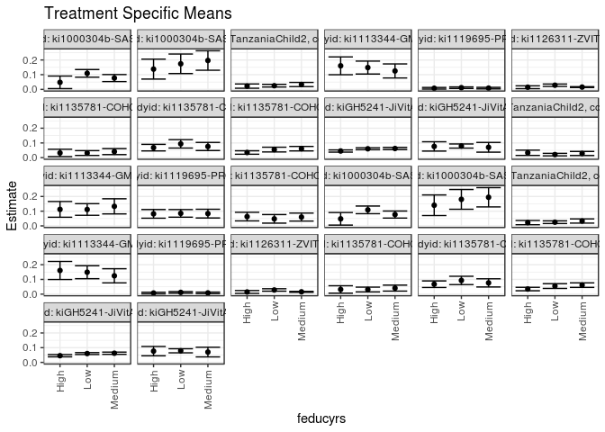

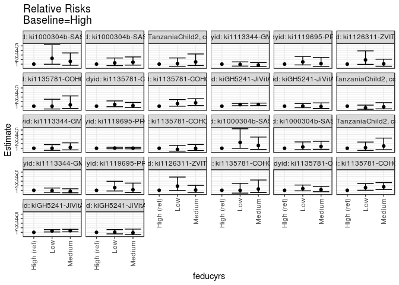

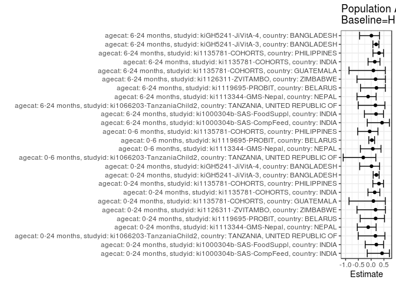

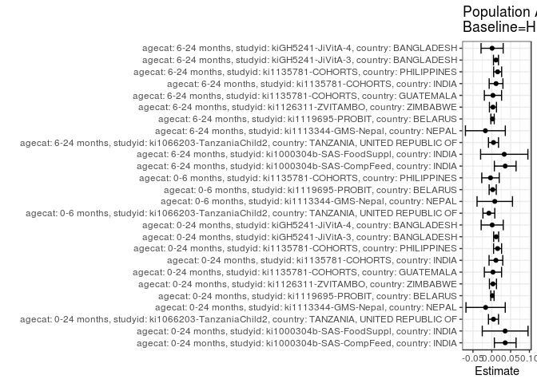

## Results Table

### Parameter: TSM

| agecat | studyid | country | intervention_level | baseline_level | estimate | ci_lower | ci_upper |
| --- | --- | --- | --- | --- | --- | --- | --- |
| 0-24 months | ki1000304b-SAS-CompFeed | INDIA | High | NA | 0.0479762 | 0.0053159 | 0.0906364 |
| 0-24 months | ki1000304b-SAS-CompFeed | INDIA | Low | NA | 0.1089371 | 0.0829270 | 0.1349472 |
| 0-24 months | ki1000304b-SAS-CompFeed | INDIA | Medium | NA | 0.0770914 | 0.0531683 | 0.1010145 |
| 0-24 months | ki1000304b-SAS-FoodSuppl | INDIA | High | NA | 0.1378513 | 0.0700869 | 0.2056157 |
| 0-24 months | ki1000304b-SAS-FoodSuppl | INDIA | Low | NA | 0.1738801 | 0.1076266 | 0.2401335 |
| 0-24 months | ki1000304b-SAS-FoodSuppl | INDIA | Medium | NA | 0.1962820 | 0.1302698 | 0.2622941 |
| 0-24 months | ki1066203-TanzaniaChild2 | TANZANIA, UNITED REPUBLIC OF | High | NA | 0.0223881 | 0.0079228 | 0.0368534 |
| 0-24 months | ki1066203-TanzaniaChild2 | TANZANIA, UNITED REPUBLIC OF | Low | NA | 0.0251736 | 0.0161255 | 0.0342217 |
| 0-24 months | ki1066203-TanzaniaChild2 | TANZANIA, UNITED REPUBLIC OF | Medium | NA | 0.0332779 | 0.0189349 | 0.0476209 |
| 0-24 months | ki1113344-GMS-Nepal | NEPAL | High | NA | 0.1602523 | 0.0997080 | 0.2207965 |
| 0-24 months | ki1113344-GMS-Nepal | NEPAL | Low | NA | 0.1483034 | 0.1044103 | 0.1921966 |
| 0-24 months | ki1113344-GMS-Nepal | NEPAL | Medium | NA | 0.1253629 | 0.0777392 | 0.1729867 |
| 0-24 months | ki1119695-PROBIT | BELARUS | High | NA | 0.0078313 | 0.0023837 | 0.0132789 |
| 0-24 months | ki1119695-PROBIT | BELARUS | Low | NA | 0.0116408 | 0.0065144 | 0.0167673 |
| 0-24 months | ki1119695-PROBIT | BELARUS | Medium | NA | 0.0087195 | 0.0035282 | 0.0139109 |
| 0-24 months | ki1126311-ZVITAMBO | ZIMBABWE | High | NA | 0.0148026 | 0.0052031 | 0.0244022 |
| 0-24 months | ki1126311-ZVITAMBO | ZIMBABWE | Low | NA | 0.0284450 | 0.0202527 | 0.0366373 |
| 0-24 months | ki1126311-ZVITAMBO | ZIMBABWE | Medium | NA | 0.0157297 | 0.0127864 | 0.0186730 |
| 0-24 months | ki1135781-COHORTS | GUATEMALA | High | NA | 0.0319149 | 0.0067764 | 0.0570534 |
| 0-24 months | ki1135781-COHORTS | GUATEMALA | Low | NA | 0.0314607 | 0.0152340 | 0.0476873 |
| 0-24 months | ki1135781-COHORTS | GUATEMALA | Medium | NA | 0.0409836 | 0.0206627 | 0.0613045 |
| 0-24 months | ki1135781-COHORTS | INDIA | High | NA | 0.0679451 | 0.0456489 | 0.0902413 |
| 0-24 months | ki1135781-COHORTS | INDIA | Low | NA | 0.0938067 | 0.0653136 | 0.1222998 |
| 0-24 months | ki1135781-COHORTS | INDIA | Medium | NA | 0.0760139 | 0.0483756 | 0.1036521 |
| 0-24 months | ki1135781-COHORTS | PHILIPPINES | High | NA | 0.0349588 | 0.0231601 | 0.0467575 |
| 0-24 months | ki1135781-COHORTS | PHILIPPINES | Low | NA | 0.0548137 | 0.0387528 | 0.0708746 |
| 0-24 months | ki1135781-COHORTS | PHILIPPINES | Medium | NA | 0.0608364 | 0.0455504 | 0.0761224 |
| 0-24 months | kiGH5241-JiVitA-3 | BANGLADESH | High | NA | 0.0451334 | 0.0375564 | 0.0527103 |
| 0-24 months | kiGH5241-JiVitA-3 | BANGLADESH | Low | NA | 0.0603175 | 0.0537497 | 0.0668853 |
| 0-24 months | kiGH5241-JiVitA-3 | BANGLADESH | Medium | NA | 0.0621788 | 0.0548029 | 0.0695546 |
| 0-24 months | kiGH5241-JiVitA-4 | BANGLADESH | High | NA | 0.0762785 | 0.0446588 | 0.1078981 |
| 0-24 months | kiGH5241-JiVitA-4 | BANGLADESH | Low | NA | 0.0788888 | 0.0649553 | 0.0928223 |
| 0-24 months | kiGH5241-JiVitA-4 | BANGLADESH | Medium | NA | 0.0704222 | 0.0372810 | 0.1035633 |
| 0-6 months | ki1066203-TanzaniaChild2 | TANZANIA, UNITED REPUBLIC OF | High | NA | 0.0331332 | 0.0152363 | 0.0510301 |
| 0-6 months | ki1066203-TanzaniaChild2 | TANZANIA, UNITED REPUBLIC OF | Low | NA | 0.0208027 | 0.0123135 | 0.0292919 |
| 0-6 months | ki1066203-TanzaniaChild2 | TANZANIA, UNITED REPUBLIC OF | Medium | NA | 0.0283598 | 0.0144962 | 0.0422235 |
| 0-6 months | ki1113344-GMS-Nepal | NEPAL | High | NA | 0.1122182 | 0.0588744 | 0.1655620 |
| 0-6 months | ki1113344-GMS-Nepal | NEPAL | Low | NA | 0.1114459 | 0.0718467 | 0.1510452 |
| 0-6 months | ki1113344-GMS-Nepal | NEPAL | Medium | NA | 0.1328249 | 0.0814771 | 0.1841727 |
| 0-6 months | ki1119695-PROBIT | BELARUS | High | NA | 0.0817958 | 0.0523820 | 0.1112096 |
| 0-6 months | ki1119695-PROBIT | BELARUS | Low | NA | 0.0851174 | 0.0592798 | 0.1109550 |
| 0-6 months | ki1119695-PROBIT | BELARUS | Medium | NA | 0.0834914 | 0.0537648 | 0.1132180 |
| 0-6 months | ki1135781-COHORTS | PHILIPPINES | High | NA | 0.0631465 | 0.0339747 | 0.0923182 |
| 0-6 months | ki1135781-COHORTS | PHILIPPINES | Low | NA | 0.0479369 | 0.0187783 | 0.0770954 |
| 0-6 months | ki1135781-COHORTS | PHILIPPINES | Medium | NA | 0.0599224 | 0.0328115 | 0.0870334 |
| 6-24 months | ki1000304b-SAS-CompFeed | INDIA | High | NA | 0.0479762 | 0.0053159 | 0.0906364 |
| 6-24 months | ki1000304b-SAS-CompFeed | INDIA | Low | NA | 0.1089371 | 0.0829270 | 0.1349472 |
| 6-24 months | ki1000304b-SAS-CompFeed | INDIA | Medium | NA | 0.0770914 | 0.0531683 | 0.1010145 |
| 6-24 months | ki1000304b-SAS-FoodSuppl | INDIA | High | NA | 0.1402555 | 0.0701863 | 0.2103247 |
| 6-24 months | ki1000304b-SAS-FoodSuppl | INDIA | Low | NA | 0.1802790 | 0.1132340 | 0.2473240 |
| 6-24 months | ki1000304b-SAS-FoodSuppl | INDIA | Medium | NA | 0.1944385 | 0.1290055 | 0.2598716 |
| 6-24 months | ki1066203-TanzaniaChild2 | TANZANIA, UNITED REPUBLIC OF | High | NA | 0.0223881 | 0.0079228 | 0.0368534 |
| 6-24 months | ki1066203-TanzaniaChild2 | TANZANIA, UNITED REPUBLIC OF | Low | NA | 0.0251736 | 0.0161255 | 0.0342217 |
| 6-24 months | ki1066203-TanzaniaChild2 | TANZANIA, UNITED REPUBLIC OF | Medium | NA | 0.0332779 | 0.0189349 | 0.0476209 |
| 6-24 months | ki1113344-GMS-Nepal | NEPAL | High | NA | 0.1608708 | 0.0995276 | 0.2222140 |
| 6-24 months | ki1113344-GMS-Nepal | NEPAL | Low | NA | 0.1489450 | 0.1048818 | 0.1930081 |
| 6-24 months | ki1113344-GMS-Nepal | NEPAL | Medium | NA | 0.1246314 | 0.0767168 | 0.1725460 |
| 6-24 months | ki1119695-PROBIT | BELARUS | High | NA | 0.0075148 | 0.0020199 | 0.0130098 |
| 6-24 months | ki1119695-PROBIT | BELARUS | Low | NA | 0.0119570 | 0.0066167 | 0.0172974 |
| 6-24 months | ki1119695-PROBIT | BELARUS | Medium | NA | 0.0084891 | 0.0033139 | 0.0136642 |
| 6-24 months | ki1126311-ZVITAMBO | ZIMBABWE | High | NA | 0.0148026 | 0.0052031 | 0.0244022 |
| 6-24 months | ki1126311-ZVITAMBO | ZIMBABWE | Low | NA | 0.0284450 | 0.0202527 | 0.0366373 |
| 6-24 months | ki1126311-ZVITAMBO | ZIMBABWE | Medium | NA | 0.0157297 | 0.0127864 | 0.0186730 |
| 6-24 months | ki1135781-COHORTS | GUATEMALA | High | NA | 0.0319149 | 0.0067764 | 0.0570534 |
| 6-24 months | ki1135781-COHORTS | GUATEMALA | Low | NA | 0.0314607 | 0.0152340 | 0.0476873 |
| 6-24 months | ki1135781-COHORTS | GUATEMALA | Medium | NA | 0.0409836 | 0.0206627 | 0.0613045 |
| 6-24 months | ki1135781-COHORTS | INDIA | High | NA | 0.0675736 | 0.0452226 | 0.0899247 |
| 6-24 months | ki1135781-COHORTS | INDIA | Low | NA | 0.0931196 | 0.0649009 | 0.1213383 |
| 6-24 months | ki1135781-COHORTS | INDIA | Medium | NA | 0.0765845 | 0.0487106 | 0.1044584 |
| 6-24 months | ki1135781-COHORTS | PHILIPPINES | High | NA | 0.0348027 | 0.0230264 | 0.0465790 |
| 6-24 months | ki1135781-COHORTS | PHILIPPINES | Low | NA | 0.0550093 | 0.0388859 | 0.0711327 |
| 6-24 months | ki1135781-COHORTS | PHILIPPINES | Medium | NA | 0.0612884 | 0.0458806 | 0.0766963 |
| 6-24 months | kiGH5241-JiVitA-3 | BANGLADESH | High | NA | 0.0456264 | 0.0379273 | 0.0533256 |
| 6-24 months | kiGH5241-JiVitA-3 | BANGLADESH | Low | NA | 0.0601248 | 0.0534983 | 0.0667513 |
| 6-24 months | kiGH5241-JiVitA-3 | BANGLADESH | Medium | NA | 0.0623531 | 0.0548490 | 0.0698573 |
| 6-24 months | kiGH5241-JiVitA-4 | BANGLADESH | High | NA | 0.0765429 | 0.0448493 | 0.1082365 |
| 6-24 months | kiGH5241-JiVitA-4 | BANGLADESH | Low | NA | 0.0789147 | 0.0649963 | 0.0928331 |
| 6-24 months | kiGH5241-JiVitA-4 | BANGLADESH | Medium | NA | 0.0701269 | 0.0372321 | 0.1030216 |

### Parameter: E(Y)

| agecat | studyid | country | intervention_level | baseline_level | estimate | ci_lower | ci_upper |
| --- | --- | --- | --- | --- | --- | --- | --- |
| 0-24 months | ki1000304b-SAS-CompFeed | INDIA | NA | NA | 0.0836390 | 0.0602327 | 0.1070453 |
| 0-24 months | ki1000304b-SAS-FoodSuppl | INDIA | NA | NA | 0.1733333 | 0.1349698 | 0.2116969 |
| 0-24 months | ki1066203-TanzaniaChild2 | TANZANIA, UNITED REPUBLIC OF | NA | NA | 0.0269142 | 0.0200799 | 0.0337484 |
| 0-24 months | ki1113344-GMS-Nepal | NEPAL | NA | NA | 0.1438240 | 0.1155088 | 0.1721392 |
| 0-24 months | ki1119695-PROBIT | BELARUS | NA | NA | 0.0094941 | 0.0051728 | 0.0138153 |
| 0-24 months | ki1126311-ZVITAMBO | ZIMBABWE | NA | NA | 0.0178887 | 0.0151586 | 0.0206188 |
| 0-24 months | ki1135781-COHORTS | GUATEMALA | NA | NA | 0.0350350 | 0.0236276 | 0.0464425 |
| 0-24 months | ki1135781-COHORTS | INDIA | NA | NA | 0.0789050 | 0.0639058 | 0.0939041 |
| 0-24 months | ki1135781-COHORTS | PHILIPPINES | NA | NA | 0.0503949 | 0.0420785 | 0.0587113 |
| 0-24 months | kiGH5241-JiVitA-3 | BANGLADESH | NA | NA | 0.0567315 | 0.0525489 | 0.0609140 |
| 0-24 months | kiGH5241-JiVitA-4 | BANGLADESH | NA | NA | 0.0773869 | 0.0653840 | 0.0893899 |
| 0-6 months | ki1066203-TanzaniaChild2 | TANZANIA, UNITED REPUBLIC OF | NA | NA | 0.0253535 | 0.0185487 | 0.0321583 |
| 0-6 months | ki1113344-GMS-Nepal | NEPAL | NA | NA | 0.1201479 | 0.0927249 | 0.1475708 |
| 0-6 months | ki1119695-PROBIT | BELARUS | NA | NA | 0.0841807 | 0.0567141 | 0.1116474 |
| 0-6 months | ki1135781-COHORTS | PHILIPPINES | NA | NA | 0.0597015 | 0.0433139 | 0.0760891 |
| 6-24 months | ki1000304b-SAS-CompFeed | INDIA | NA | NA | 0.0836390 | 0.0602327 | 0.1070453 |
| 6-24 months | ki1000304b-SAS-FoodSuppl | INDIA | NA | NA | 0.1733333 | 0.1349698 | 0.2116969 |
| 6-24 months | ki1066203-TanzaniaChild2 | TANZANIA, UNITED REPUBLIC OF | NA | NA | 0.0269142 | 0.0200799 | 0.0337484 |
| 6-24 months | ki1113344-GMS-Nepal | NEPAL | NA | NA | 0.1438240 | 0.1155088 | 0.1721392 |
| 6-24 months | ki1119695-PROBIT | BELARUS | NA | NA | 0.0094941 | 0.0051728 | 0.0138153 |
| 6-24 months | ki1126311-ZVITAMBO | ZIMBABWE | NA | NA | 0.0178887 | 0.0151586 | 0.0206188 |
| 6-24 months | ki1135781-COHORTS | GUATEMALA | NA | NA | 0.0350350 | 0.0236276 | 0.0464425 |
| 6-24 months | ki1135781-COHORTS | INDIA | NA | NA | 0.0789050 | 0.0639058 | 0.0939041 |
| 6-24 months | ki1135781-COHORTS | PHILIPPINES | NA | NA | 0.0503949 | 0.0420785 | 0.0587113 |
| 6-24 months | kiGH5241-JiVitA-3 | BANGLADESH | NA | NA | 0.0567315 | 0.0525489 | 0.0609140 |
| 6-24 months | kiGH5241-JiVitA-4 | BANGLADESH | NA | NA | 0.0773869 | 0.0653840 | 0.0893899 |

### Parameter: RR

| agecat | studyid | country | intervention_level | baseline_level | estimate | ci_lower | ci_upper |
| --- | --- | --- | --- | --- | --- | --- | --- |
| 0-24 months | ki1000304b-SAS-CompFeed | INDIA | High | High | 1.0000000 | 1.0000000 | 1.000000 |
| 0-24 months | ki1000304b-SAS-CompFeed | INDIA | Low | High | 2.2706501 | 0.9774568 | 5.274762 |
| 0-24 months | ki1000304b-SAS-CompFeed | INDIA | Medium | High | 1.6068688 | 0.7466768 | 3.458025 |
| 0-24 months | ki1000304b-SAS-FoodSuppl | INDIA | High | High | 1.0000000 | 1.0000000 | 1.000000 |
| 0-24 months | ki1000304b-SAS-FoodSuppl | INDIA | Low | High | 1.2613596 | 0.6790245 | 2.343108 |
| 0-24 months | ki1000304b-SAS-FoodSuppl | INDIA | Medium | High | 1.4238674 | 0.7853711 | 2.581453 |
| 0-24 months | ki1066203-TanzaniaChild2 | TANZANIA, UNITED REPUBLIC OF | High | High | 1.0000000 | 1.0000000 | 1.000000 |
| 0-24 months | ki1066203-TanzaniaChild2 | TANZANIA, UNITED REPUBLIC OF | Low | High | 1.1244213 | 0.5368195 | 2.355211 |
| 0-24 months | ki1066203-TanzaniaChild2 | TANZANIA, UNITED REPUBLIC OF | Medium | High | 1.4864115 | 0.6836450 | 3.231822 |
| 0-24 months | ki1113344-GMS-Nepal | NEPAL | High | High | 1.0000000 | 1.0000000 | 1.000000 |
| 0-24 months | ki1113344-GMS-Nepal | NEPAL | Low | High | 0.9254373 | 0.5725906 | 1.495718 |
| 0-24 months | ki1113344-GMS-Nepal | NEPAL | Medium | High | 0.7822850 | 0.4577972 | 1.336771 |
| 0-24 months | ki1119695-PROBIT | BELARUS | High | High | 1.0000000 | 1.0000000 | 1.000000 |
| 0-24 months | ki1119695-PROBIT | BELARUS | Low | High | 1.4864449 | 0.8239746 | 2.681537 |
| 0-24 months | ki1119695-PROBIT | BELARUS | Medium | High | 1.1134177 | 0.5047922 | 2.455860 |
| 0-24 months | ki1126311-ZVITAMBO | ZIMBABWE | High | High | 1.0000000 | 1.0000000 | 1.000000 |
| 0-24 months | ki1126311-ZVITAMBO | ZIMBABWE | Low | High | 1.9216182 | 0.9451494 | 3.906913 |
| 0-24 months | ki1126311-ZVITAMBO | ZIMBABWE | Medium | High | 1.0626274 | 0.5410654 | 2.086951 |
| 0-24 months | ki1135781-COHORTS | GUATEMALA | High | High | 1.0000000 | 1.0000000 | 1.000000 |
| 0-24 months | ki1135781-COHORTS | GUATEMALA | Low | High | 0.9857678 | 0.3844846 | 2.527379 |
| 0-24 months | ki1135781-COHORTS | GUATEMALA | Medium | High | 1.2841530 | 0.5062921 | 3.257110 |
| 0-24 months | ki1135781-COHORTS | INDIA | High | High | 1.0000000 | 1.0000000 | 1.000000 |
| 0-24 months | ki1135781-COHORTS | INDIA | Low | High | 1.3806253 | 0.8827989 | 2.159185 |
| 0-24 months | ki1135781-COHORTS | INDIA | Medium | High | 1.1187539 | 0.6856338 | 1.825479 |
| 0-24 months | ki1135781-COHORTS | PHILIPPINES | High | High | 1.0000000 | 1.0000000 | 1.000000 |
| 0-24 months | ki1135781-COHORTS | PHILIPPINES | Low | High | 1.5679525 | 1.0026623 | 2.451947 |
| 0-24 months | ki1135781-COHORTS | PHILIPPINES | Medium | High | 1.7402327 | 1.1422079 | 2.651365 |
| 0-24 months | kiGH5241-JiVitA-3 | BANGLADESH | High | High | 1.0000000 | 1.0000000 | 1.000000 |
| 0-24 months | kiGH5241-JiVitA-3 | BANGLADESH | Low | High | 1.3364288 | 1.1034714 | 1.618567 |
| 0-24 months | kiGH5241-JiVitA-3 | BANGLADESH | Medium | High | 1.3776677 | 1.1284559 | 1.681916 |
| 0-24 months | kiGH5241-JiVitA-4 | BANGLADESH | High | High | 1.0000000 | 1.0000000 | 1.000000 |
| 0-24 months | kiGH5241-JiVitA-4 | BANGLADESH | Low | High | 1.0342214 | 0.6643097 | 1.610113 |
| 0-24 months | kiGH5241-JiVitA-4 | BANGLADESH | Medium | High | 0.9232244 | 0.4942002 | 1.724692 |
| 0-6 months | ki1066203-TanzaniaChild2 | TANZANIA, UNITED REPUBLIC OF | High | High | 1.0000000 | 1.0000000 | 1.000000 |
| 0-6 months | ki1066203-TanzaniaChild2 | TANZANIA, UNITED REPUBLIC OF | Low | High | 0.6278511 | 0.3189189 | 1.236041 |
| 0-6 months | ki1066203-TanzaniaChild2 | TANZANIA, UNITED REPUBLIC OF | Medium | High | 0.8559349 | 0.4132718 | 1.772742 |
| 0-6 months | ki1113344-GMS-Nepal | NEPAL | High | High | 1.0000000 | 1.0000000 | 1.000000 |
| 0-6 months | ki1113344-GMS-Nepal | NEPAL | Low | High | 0.9931182 | 0.5479982 | 1.799794 |
| 0-6 months | ki1113344-GMS-Nepal | NEPAL | Medium | High | 1.1836307 | 0.6406439 | 2.186834 |
| 0-6 months | ki1119695-PROBIT | BELARUS | High | High | 1.0000000 | 1.0000000 | 1.000000 |
| 0-6 months | ki1119695-PROBIT | BELARUS | Low | High | 1.0406082 | 0.8884000 | 1.218894 |
| 0-6 months | ki1119695-PROBIT | BELARUS | Medium | High | 1.0207297 | 0.8699107 | 1.197697 |
| 0-6 months | ki1135781-COHORTS | PHILIPPINES | High | High | 1.0000000 | 1.0000000 | 1.000000 |
| 0-6 months | ki1135781-COHORTS | PHILIPPINES | Low | High | 0.7591378 | 0.3534532 | 1.630457 |
| 0-6 months | ki1135781-COHORTS | PHILIPPINES | Medium | High | 0.9489436 | 0.4968806 | 1.812294 |
| 6-24 months | ki1000304b-SAS-CompFeed | INDIA | High | High | 1.0000000 | 1.0000000 | 1.000000 |
| 6-24 months | ki1000304b-SAS-CompFeed | INDIA | Low | High | 2.2706501 | 0.9774568 | 5.274762 |
| 6-24 months | ki1000304b-SAS-CompFeed | INDIA | Medium | High | 1.6068688 | 0.7466768 | 3.458025 |
| 6-24 months | ki1000304b-SAS-FoodSuppl | INDIA | High | High | 1.0000000 | 1.0000000 | 1.000000 |
| 6-24 months | ki1000304b-SAS-FoodSuppl | INDIA | Low | High | 1.2853616 | 0.6922847 | 2.386525 |
| 6-24 months | ki1000304b-SAS-FoodSuppl | INDIA | Medium | High | 1.3863168 | 0.7593092 | 2.531083 |
| 6-24 months | ki1066203-TanzaniaChild2 | TANZANIA, UNITED REPUBLIC OF | High | High | 1.0000000 | 1.0000000 | 1.000000 |
| 6-24 months | ki1066203-TanzaniaChild2 | TANZANIA, UNITED REPUBLIC OF | Low | High | 1.1244213 | 0.5368195 | 2.355211 |
| 6-24 months | ki1066203-TanzaniaChild2 | TANZANIA, UNITED REPUBLIC OF | Medium | High | 1.4864115 | 0.6836450 | 3.231822 |
| 6-24 months | ki1113344-GMS-Nepal | NEPAL | High | High | 1.0000000 | 1.0000000 | 1.000000 |
| 6-24 months | ki1113344-GMS-Nepal | NEPAL | Low | High | 0.9258669 | 0.5713819 | 1.500274 |
| 6-24 months | ki1113344-GMS-Nepal | NEPAL | Medium | High | 0.7747299 | 0.4507258 | 1.331644 |
| 6-24 months | ki1119695-PROBIT | BELARUS | High | High | 1.0000000 | 1.0000000 | 1.000000 |
| 6-24 months | ki1119695-PROBIT | BELARUS | Low | High | 1.5911248 | 0.8485688 | 2.983468 |
| 6-24 months | ki1119695-PROBIT | BELARUS | Medium | High | 1.1296446 | 0.4946476 | 2.579810 |
| 6-24 months | ki1126311-ZVITAMBO | ZIMBABWE | High | High | 1.0000000 | 1.0000000 | 1.000000 |
| 6-24 months | ki1126311-ZVITAMBO | ZIMBABWE | Low | High | 1.9216182 | 0.9451494 | 3.906913 |
| 6-24 months | ki1126311-ZVITAMBO | ZIMBABWE | Medium | High | 1.0626274 | 0.5410654 | 2.086951 |
| 6-24 months | ki1135781-COHORTS | GUATEMALA | High | High | 1.0000000 | 1.0000000 | 1.000000 |
| 6-24 months | ki1135781-COHORTS | GUATEMALA | Low | High | 0.9857678 | 0.3844846 | 2.527379 |
| 6-24 months | ki1135781-COHORTS | GUATEMALA | Medium | High | 1.2841530 | 0.5062921 | 3.257110 |
| 6-24 months | ki1135781-COHORTS | INDIA | High | High | 1.0000000 | 1.0000000 | 1.000000 |
| 6-24 months | ki1135781-COHORTS | INDIA | Low | High | 1.3780454 | 0.8798327 | 2.158375 |
| 6-24 months | ki1135781-COHORTS | INDIA | Medium | High | 1.1333488 | 0.6930427 | 1.853392 |
| 6-24 months | ki1135781-COHORTS | PHILIPPINES | High | High | 1.0000000 | 1.0000000 | 1.000000 |
| 6-24 months | ki1135781-COHORTS | PHILIPPINES | Low | High | 1.5806054 | 1.0101307 | 2.473258 |
| 6-24 months | ki1135781-COHORTS | PHILIPPINES | Medium | High | 1.7610253 | 1.1553644 | 2.684184 |
| 6-24 months | kiGH5241-JiVitA-3 | BANGLADESH | High | High | 1.0000000 | 1.0000000 | 1.000000 |
| 6-24 months | kiGH5241-JiVitA-3 | BANGLADESH | Low | High | 1.3177621 | 1.0889581 | 1.594641 |
| 6-24 months | kiGH5241-JiVitA-3 | BANGLADESH | Medium | High | 1.3666002 | 1.1179508 | 1.670553 |
| 6-24 months | kiGH5241-JiVitA-4 | BANGLADESH | High | High | 1.0000000 | 1.0000000 | 1.000000 |
| 6-24 months | kiGH5241-JiVitA-4 | BANGLADESH | Low | High | 1.0309864 | 0.6627078 | 1.603924 |
| 6-24 months | kiGH5241-JiVitA-4 | BANGLADESH | Medium | High | 0.9161776 | 0.4911594 | 1.708979 |

### Parameter: PAR

| agecat | studyid | country | intervention_level | baseline_level | estimate | ci_lower | ci_upper |
| --- | --- | --- | --- | --- | --- | --- | --- |
| 0-24 months | ki1000304b-SAS-CompFeed | INDIA | High | NA | 0.0356629 | 0.0068211 | 0.0645046 |
| 0-24 months | ki1000304b-SAS-FoodSuppl | INDIA | High | NA | 0.0354820 | -0.0253230 | 0.0962870 |
| 0-24 months | ki1066203-TanzaniaChild2 | TANZANIA, UNITED REPUBLIC OF | High | NA | 0.0045261 | -0.0088113 | 0.0178635 |
| 0-24 months | ki1113344-GMS-Nepal | NEPAL | High | NA | -0.0164282 | -0.0685808 | 0.0357244 |
| 0-24 months | ki1119695-PROBIT | BELARUS | High | NA | 0.0016627 | -0.0027447 | 0.0060702 |
| 0-24 months | ki1126311-ZVITAMBO | ZIMBABWE | High | NA | 0.0030861 | -0.0062537 | 0.0124258 |
| 0-24 months | ki1135781-COHORTS | GUATEMALA | High | NA | 0.0031201 | -0.0197759 | 0.0260162 |
| 0-24 months | ki1135781-COHORTS | INDIA | High | NA | 0.0109599 | -0.0072556 | 0.0291754 |
| 0-24 months | ki1135781-COHORTS | PHILIPPINES | High | NA | 0.0154361 | 0.0047909 | 0.0260813 |
| 0-24 months | kiGH5241-JiVitA-3 | BANGLADESH | High | NA | 0.0115981 | 0.0049960 | 0.0182002 |
| 0-24 months | kiGH5241-JiVitA-4 | BANGLADESH | High | NA | 0.0011084 | -0.0282191 | 0.0304359 |
| 0-6 months | ki1066203-TanzaniaChild2 | TANZANIA, UNITED REPUBLIC OF | High | NA | -0.0077797 | -0.0235015 | 0.0079421 |
| 0-6 months | ki1113344-GMS-Nepal | NEPAL | High | NA | 0.0079297 | -0.0391711 | 0.0550304 |
| 0-6 months | ki1119695-PROBIT | BELARUS | High | NA | 0.0023849 | -0.0070549 | 0.0118247 |
| 0-6 months | ki1135781-COHORTS | PHILIPPINES | High | NA | -0.0034450 | -0.0266360 | 0.0197460 |
| 6-24 months | ki1000304b-SAS-CompFeed | INDIA | High | NA | 0.0356629 | 0.0068211 | 0.0645046 |
| 6-24 months | ki1000304b-SAS-FoodSuppl | INDIA | High | NA | 0.0330779 | -0.0297364 | 0.0958922 |
| 6-24 months | ki1066203-TanzaniaChild2 | TANZANIA, UNITED REPUBLIC OF | High | NA | 0.0045261 | -0.0088113 | 0.0178635 |
| 6-24 months | ki1113344-GMS-Nepal | NEPAL | High | NA | -0.0170468 | -0.0700166 | 0.0359231 |
| 6-24 months | ki1119695-PROBIT | BELARUS | High | NA | 0.0019792 | -0.0025037 | 0.0064622 |
| 6-24 months | ki1126311-ZVITAMBO | ZIMBABWE | High | NA | 0.0030861 | -0.0062537 | 0.0124258 |
| 6-24 months | ki1135781-COHORTS | GUATEMALA | High | NA | 0.0031201 | -0.0197759 | 0.0260162 |
| 6-24 months | ki1135781-COHORTS | INDIA | High | NA | 0.0113313 | -0.0069458 | 0.0296084 |
| 6-24 months | ki1135781-COHORTS | PHILIPPINES | High | NA | 0.0155922 | 0.0049661 | 0.0262182 |
| 6-24 months | kiGH5241-JiVitA-3 | BANGLADESH | High | NA | 0.0111050 | 0.0044505 | 0.0177596 |
| 6-24 months | kiGH5241-JiVitA-4 | BANGLADESH | High | NA | 0.0008441 | -0.0285484 | 0.0302365 |

### Parameter: PAF

| agecat | studyid | country | intervention_level | baseline_level | estimate | ci_lower | ci_upper |
| --- | --- | --- | --- | --- | --- | --- | --- |
| 0-24 months | ki1000304b-SAS-CompFeed | INDIA | High | NA | 0.4263903 | -0.1519905 | 0.7143830 |
| 0-24 months | ki1000304b-SAS-FoodSuppl | INDIA | High | NA | 0.2047040 | -0.2320390 | 0.4866269 |
| 0-24 months | ki1066203-TanzaniaChild2 | TANZANIA, UNITED REPUBLIC OF | High | NA | 0.1681678 | -0.5060612 | 0.5405599 |
| 0-24 months | ki1113344-GMS-Nepal | NEPAL | High | NA | -0.1142245 | -0.5422482 | 0.1950088 |
| 0-24 months | ki1119695-PROBIT | BELARUS | High | NA | 0.1751355 | -0.4290906 | 0.5238921 |
| 0-24 months | ki1126311-ZVITAMBO | ZIMBABWE | High | NA | 0.1725146 | -0.5539660 | 0.5593648 |
| 0-24 months | ki1135781-COHORTS | GUATEMALA | High | NA | 0.0890578 | -0.8653949 | 0.5551528 |
| 0-24 months | ki1135781-COHORTS | INDIA | High | NA | 0.1388998 | -0.1240613 | 0.3403441 |
| 0-24 months | ki1135781-COHORTS | PHILIPPINES | High | NA | 0.3063029 | 0.0680193 | 0.4836635 |
| 0-24 months | kiGH5241-JiVitA-3 | BANGLADESH | High | NA | 0.2044387 | 0.0791515 | 0.3126797 |
| 0-24 months | kiGH5241-JiVitA-4 | BANGLADESH | High | NA | 0.0143234 | -0.4477997 | 0.3289415 |
| 0-6 months | ki1066203-TanzaniaChild2 | TANZANIA, UNITED REPUBLIC OF | High | NA | -0.3068493 | -1.0925680 | 0.1838472 |
| 0-6 months | ki1113344-GMS-Nepal | NEPAL | High | NA | 0.0659993 | -0.4204537 | 0.3858601 |
| 0-6 months | ki1119695-PROBIT | BELARUS | High | NA | 0.0283310 | -0.0913915 | 0.1349203 |
| 0-6 months | ki1135781-COHORTS | PHILIPPINES | High | NA | -0.0577031 | -0.5262029 | 0.2669810 |
| 6-24 months | ki1000304b-SAS-CompFeed | INDIA | High | NA | 0.4263903 | -0.1519905 | 0.7143830 |
| 6-24 months | ki1000304b-SAS-FoodSuppl | INDIA | High | NA | 0.1908338 | -0.2631918 | 0.4816703 |
| 6-24 months | ki1066203-TanzaniaChild2 | TANZANIA, UNITED REPUBLIC OF | High | NA | 0.1681678 | -0.5060612 | 0.5405599 |
| 6-24 months | ki1113344-GMS-Nepal | NEPAL | High | NA | -0.1185252 | -0.5540436 | 0.1949397 |
| 6-24 months | ki1119695-PROBIT | BELARUS | High | NA | 0.2084721 | -0.4163633 | 0.5576584 |
| 6-24 months | ki1126311-ZVITAMBO | ZIMBABWE | High | NA | 0.1725146 | -0.5539660 | 0.5593648 |
| 6-24 months | ki1135781-COHORTS | GUATEMALA | High | NA | 0.0890578 | -0.8653949 | 0.5551528 |
| 6-24 months | ki1135781-COHORTS | INDIA | High | NA | 0.1436074 | -0.1206034 | 0.3455238 |
| 6-24 months | ki1135781-COHORTS | PHILIPPINES | High | NA | 0.3094000 | 0.0715285 | 0.4863296 |
| 6-24 months | kiGH5241-JiVitA-3 | BANGLADESH | High | NA | 0.1957471 | 0.0691853 | 0.3051005 |
| 6-24 months | kiGH5241-JiVitA-4 | BANGLADESH | High | NA | 0.0109070 | -0.4521255 | 0.3262945 |